# Modified DeGAUSS

Aki Shiroshita

2025-10-29

Aki Shiroshita (Epidemiology PhD student, akihiro.shiroshita@vanderbilt.edu) developed a tailored version of DeGAUSS specifically for the EV project.

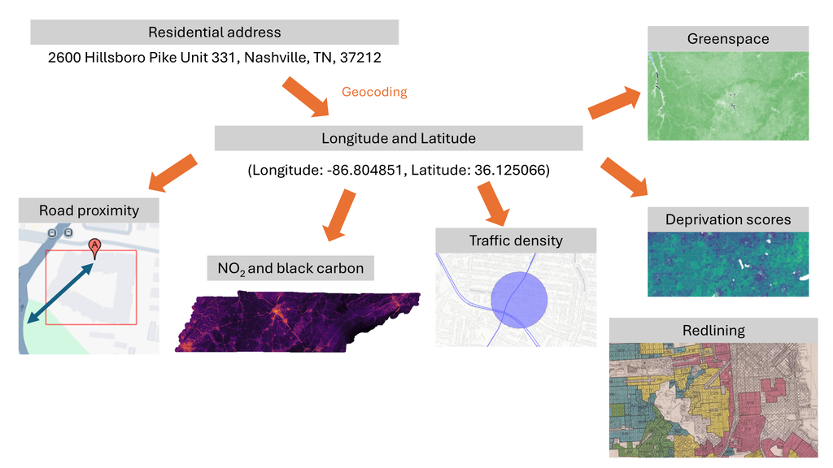

### About Original DeGAUSS

[DeGAUSS](https://degauss.org/) is designed to derive environmental variables while preserving the privacy of protected health information (PHI). It uses Docker images to process address data, Users upload a CSV file containing address information and receive an output file with various environmental variables.

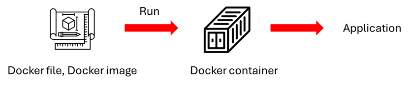

### Limitations of Original DeGAUSS

Original DeGAUSS may not be so flexible.

- Not optimized for very large datasets.
- Requires input and output files to be stored in the same folder.
- Does not support creation of custom variables.

### Improvements in the Modified DeGAUSS

- Avoid reliance on Docker, using Podman only for part of the process. (VUMC moved from Docker to Podman in October 2025)
- Utilize C and C++ in the backend wherever possible.
- Enable parallel processing with multiple cores. (Windows OS and Podman setups don’t support FIFOs used by internally in the original DeGAUSS for parallel geocoding)
- Restrict environmental data to Tennessee only, not the entire U.S.

Modified DeGAUSS provides clean, processed output files with all PHI removed.

### What can we get through Modified DeGAUSS?

| Category | Variable name | Data source | Description |
| --- | --- | --- | --- |
| **Parsing and normalizing** | `address` | libpostal | cleaned address |
| **Geocoding** | `lon` | TIGER/Line Street Range Address | longitude and latitude |
|  | `lat` | TIGER/Line Street Range Address | longitude and latitude |
| **Road proximity** | `dist_to_1100` | U.S. Census Bureau | distance (meters) to the nearest S1100 road |
|  | `dist_to_1200` | U.S. Census Bureau | distance (meters) to the nearest S1200 road |
|  | `length_1100` | U.S. Census Bureau | length (meters) of S1100 roads within a 400 m buffer |
|  | `length_1200` | U.S. Census Bureau | length (meters) of S1200 roads within a 400 m buffer |
| **Traffic density** | `length_moving` | U.S. Department of Transportation Federal Highway Administration | total length of interstates, expressways, and freeways (meters) |
|  | `length_stop_go` | U.S. Department of Transportation Federal Highway Administration | total length of arterial roads (meters) |
|  | `vehicle_meters_moving` | U.S. Department of Transportation Federal Highway Administration | average daily number of vehicles multiplied by the length of interstates, expressways, and freeways (vehicle-meters) |
|  | `vehicle_meters_stop_go` | U.S. Department of Transportation Federal Highway Administration | average daily number of vehicles multiplied by the length of arterial roads (vehicle-meters) |
|  | `truck_meters_moving` | U.S. Department of Transportation Federal Highway Administration | average daily number of trucks multiplied by the length of interstates, expressways, and freeways (truck-meters) |
|  | `truck_meters_stop_go` | U.S. Department of Transportation Federal Highway Administration | average daily number of trucks multiplied by the length of arterial roads (truck-meters) |
| **New road proximity and traffic density** | `dist_near` | U.S. Department of Transportation Federal Highway Administration | distance (meters) to the nearest interstates, expressways, or freeways |
|  | `aadt_near` | U.S. Department of Transportation Federal Highway Administration | average daily number of vehicles of the nearest interstates, expressways, or freeways |
| **Redlining categories** | `redlining` | Mapping Inequality | Historic HOLC classifications (A, B, C, and D) |
| **Greenspace** | `evi_500` | LP DAAC MOD13Q1 | average enhanced vegetation index within a 500 meter buffer radius |
|  | `evi_1500` | LP DAAC MOD13Q1 | average enhanced vegetation index within a 1500 meter buffer radius |
|  | `evi_2500` | LP DAAC MOD13Q1 | average enhanced vegetation index within a 2500 meter buffer radius |
| **Deprivation score** | `fraction_assisted_incom` | 2015 American Community Survey | fraction of households receiving public assistance income or food stamps or SNAP in the past 12 months |
|  | `fraction_high_school_edu` | 2015 American Community Survey | fraction of population 25 and older with educational attainment of at least high school graduation (includes GED equivalency) |
|  | `median_income` | 2015 American Community Survey | median household income in the past 12 months in 2015 inflation-adjusted dollars |
|  | `fraction_no_health_ins` | 2015 American Community Survey | fraction of population with no health insurance coverage |
|  | `fraction_poverty` | 2015 American Community Survey | fraction of population with income in past 12 months below poverty level |
|  | `fraction_vacant_housing` | 2015 American Community Survey | fraction of houses that are vacant |
|  | `dep_index` | 2015 American Community Survey | composite measure of the 6 variables above |
| **Air pollutants** | `average_no2_infancy` | Original Schwartz model | Average monthly NO₂ levels during the exposure period |
|  | `average_bc_infancy` | Provided by Kai Zhang | Average monthly black carbon levels during the exposure period |

In addition, you can obtain the following information if needed:

- Indicator of whether each child experienced relocation and changes in environmental exposures (e.g., moving closer to or farther from major roads).
- Number of children per census block (blocks with fewer than 11 children are masked as “<11”).
- A wide range of deprivation scores: ADI, SVI, COI, EJI, CRE, DCI, NDI NSES, SDI, and EQI, etc.

### How to Use Modified DeGAUSS

**Step-by-Step Instructions**

1. Install Podman:
- [Podman](https://github.com/containers/podman/blob/main/docs/tutorials/podman-for-windows.md) can be a bit tricky to use. Even if Podman is available on the same server environment, you’ll need to set it up independently on your system.
- Install Podman: As of October 29, 2025, the latest version is podman-installer-windows-amd64.exe (sha256:5e97bd3a56eba7302c94a2b11a8a639f513830c228d27f9cda7e557a77bd4379)
- After installation, run the following commands to initialize and start Podman

```
podman machine init
```

- Check the status and start the Podman machine

```
podman machine start
```

- Prepare the necessary Docker containers so that we avoid pulling Docker image from the public repository every time we run the command.

```
podman run -it -d --name gs --entrypoint /bin/bash ghcr.io/degauss-org/postal:0.1.4
podman run -it -d --name gs2 --entrypoint /bin/bash degauss/geocoder:3.0
```

2. Navigate to the Folder:
- Map your shared drive containing address information to our Windows server

Note: Your data will remain on the shared drive and will never leave the VUMC environment.The server will load data into memory for processing, but data will not be stored in local server folders. Any temporary cache generated during processing will be removed.

- Navigate to the folder “modified_degauss” on the Windows server (Cqshealth.dhcp.mc.vanderbilt.edu).
3. Open R Studio in the folder “modified_degauss”:
- Launch R Studio.

Note: It may take 1–2 minutes to open, as the R Studio settings have been customized for this project.

4. Run R Script:
- Open the file `modified_degauss_run_child.R` or `modified_degauss_run_dyad.R`.

If you’re using my program for the first time, please run the following command to replicate my environment:

```
install.packages('renv')
library(renv)
renv::activate()
renv::restore()
```

- Provide the following paths:

The path to the input folder containing the address data and the file name

The path to the output folder where you’d like to store the processed data after removing all PHI data

The path to the temporary folder to store intermediate files containing PHI

- Execute the remaining script.
5. Navigate to the output Files:

Processed data will be saved in any folder of your choice.

This folder contains CSV files, including: `tract.csv` (used for subject selection flow), `final_data.csv` (the final dataset for sharing with other researchers, with all PHI removed), `tab_census.csv` (census tract tabulation data), and `tab_relocation.csv` (relocation information).”

### Tips and tricks

- Parallel processes require CPU cores and memory. If your system doesn’t have enough resources, processes can fail. $\rightarrow$ Reduce the number of workers used by setting the multisession plan to use fewer workers

### Detailed description of what Modified DeGAUSS is doing.

1. `modified_degauss_run_child.R`

This is the main script (index file) that specifies the folder structure and file paths for input and output data. All subsequent scripts are called or sourced from here.

2. `R/initial_set_up.R`

This script ensures that Podman is properly configured and running. It also loads all required R packages and custom functions used.

3. `R/child_cohort_preparation_simple.R`

This script prepares the child cohort data before address standardization and geocoding.

In the original dataset, BEG and END are given in year–month format:

| recip | TN_DOB | BEG | END |
| --- | --- | --- | --- |
| 1 | 2010-10-14 | 2010-10 | 2010-10 |
| 1 | 2010-10-14 | 2011-12 | 2011-12 |
| 2 | 2022-01-06 | 2022-01 | 2022-04 |

From here, Tan converts these to the first day of the month in SAS:

| recip | TN_DOB | BEG | END |
| --- | --- | --- | --- |
| 1 | 2010-10-14 | 2010-10-01 | 2010-10-01 |
| 1 | 2010-10-14 | 2011-12-01 | 2011-12-01 |
| 2 | 2022-01-06 | 2022-01-01 | 2022-04-01 |

`R/child_cohort_preparation_simple.R` keeps only address records overlapping with the exposure period, such as infancy (e.g., from birth to 1 year).

4. `R/parsing.R`

This script parses and normalizes raw addresses using `libpostal` to improve match rates in geocoding. `libpostal` is a machine learning–based address parser trained on OpenStreetMap data.

The environment for libpostal is created using Podman, based on [ghcr.io/degauss-org/postal:0.1.4](https://degauss.org/postal/).

Each raw address should end with a 5-digit ZIP code, as the geocoding algorithm uses it as the initial search key.

Example of the input file

| recip | TN_DOB | BEG | END | Address |
| --- | --- | --- | --- | --- |
| 1 | 2010-10-14 | 2010-10-01 | 2010-10-01 | 2600 Hillsboro Pike, Nashville, TN, 37212 |

Normalized results (from [the official website of libpostal](https://github.com/openvenues/libpostal) )

| Input | Output (may be multiple in libpostal) |
| --- | --- |
| One-hundred twenty E 96th St | 120 east 96th street |
| C/ Ocho, P.I. 4 | calle 8 polígono industrial 4 |
| V XX Settembre, 20 | via 20 settembre 20 |
| Quatre vingt douze R. de l’Église | 92 rue de l eglise |
| ул Каретный Ряд, д 4, строение 7 | улица каретныи ряд дом 4 строение 7 |
| ул Каретный Ряд, д 4, строение 7 | ulitsa karetnyy ryad dom 4 stroyeniye 7 |
| Marktstraße 14 | markt strasse 14 |

**However, in TennCare data, this process sometimes dropped ZIP codes unintentionally.** **To avoid this issue, I ultimately chose to bypass that specific normalization step.**

4. `R/geocoding.R`

This is the most time-consuming part of the pipeline. It performs address geocoding using the Ruby gem `Geocoder-US-2.0.4`.

The algorithm applies fuzzy matching, and low-confidence results are removed. The Ruby and SQL geocoding environment is built using [degauss/geocoder:3.0](https://degauss.org/geocoder/).

The data source of address is TIGER/Line Address Range files (2021) from the U.S. Census Bureau.

**Post-geocoding cleanup**

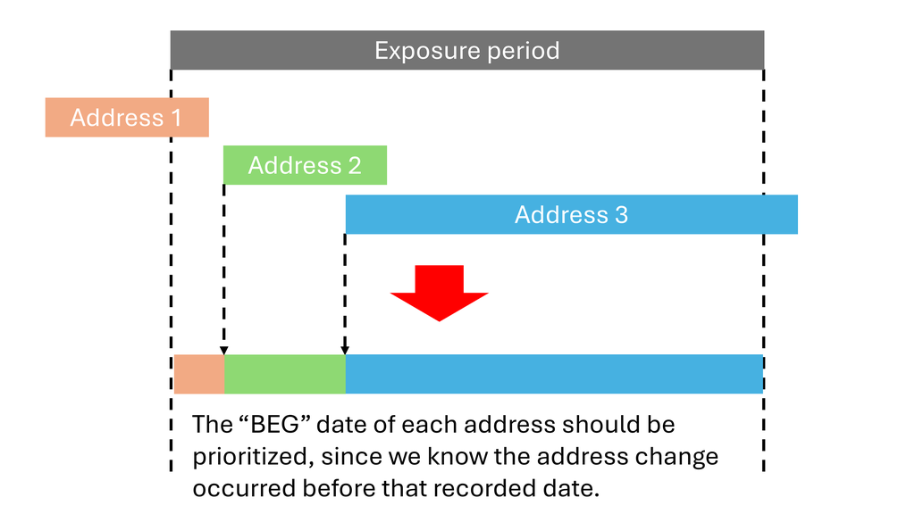

The script then adjusts address timelines to match each child’s exposure period. It creates a single continuous time span, with a total of 365 or 366 days for each child.

- Trimming timeline edges:

The start date of the first address is trimmed so it doesn’t precede the child’s date of birth.

The end date of the last address is trimmed so it doesn’t extend beyond the first birthday.

- Resolving gaps and overlaps:

If a gap exists between consecutive address periods, the end date of the earlier record is set to one day before the next record starts.

If an overlap exists, the end date of the earlier record is adjusted similarly.

5. `R/census.R`

This script appends census and redlining variables to each address.

Adds FIPS codes (census tract and block group IDs) for both 2010 and 2020: [TIGER boundary files](https://www2.census.gov/geo/tiger/) (restricted to Tennessee)

Adds Home Owners’ Loan Corporation (HOLC) redlining grades (A, B, C, D): [the University of Richmond](https://dsl.richmond.edu/panorama/redlining/data)

6. `R/road.R`

This script calculates the shortest distance to the nearest primary and secondary roads (separately).

Road data are from TIGER 2011, accessed via the R tigris package. The data source is [U.S. Census Bureau TIGER/Line Files](https://www.census.gov/geographies/mapping-files/time-series/geo/tiger-line-file.html).

I chose the 2011 data because it is the earliest year for which primary and secondary road shapefiles are available.

7. `R/green.R`

This script calculates the average Enhanced Vegetation Index (EVI) around each residential address, which serves as a measure of surrounding greenness.

EVI data are derived from [LP DAAC MOD13Q1](https://www.earthdata.nasa.gov/centers/lp-daac), a product of NASA’s Land Processes Distributed Active Archive Center (LP DAAC). A cloud-free composite EVI raster at 250 × 250 m resolution was created by assembling individual remote-sensing images collected between June 10 and June 25, 2018, by [Professor Cole Brokamp](https://github.com/degauss-org/greenspace).

8. `R/dep_index.R`

For a more comprehensive set of indices, use `dep_index_britt.R`, which generates a separate dataset containing: ADI, SVI, COI, EJI, CRE, DCI, NDI, NSES, SDI, and EQI.

9. `R/aadt.R`

This script calculates Average annual daily traffic within a 400-meter buffer radius of each residential address × road length for interstates, expressways, and freeways.

Traffic and road data were obtained from the U.S. Department of Transportation, Federal Highway Administration, using [the Highway Performance Monitoring System (HPMS) dataset](https://www.fhwa.dot.gov/policyinformation/hpms.cfm) for 2014, the earliest year available for both vehicle and truck traffic volumes.

It calculates the following metrics:

- Total length of interstates, expressways, and freeways (meters)
- Total length of arterial roads (meters)
- Average daily vehicles × length of moving roads
- Average daily vehicles × length of stop-and-go roads
- Average daily trucks × length of moving roads
- Average daily trucks × length of stop-and-go roads
10. `R/road_and_aadt.R`

Because road proximity (from TIGER) and traffic density (from HPMS) are from different data sources, this script integrates both to define a combined exposure metric. It calculates road proximity and Average Annual Daily Traffic (AADT) for interstates, expressways, and freeways using the HPMS dataset, allowing evaluation of the interaction between proximity to major roads and the traffic volume along those roads.

11. `R/no2_monthly.R`

This script estimates average NO₂ exposure during the defined exposure period. NO₂ estimates provided by [Professor Joel Schwartz](https://dataverse.harvard.edu/dataset.xhtml?persistentId=doi:10.7910/DVN/LUFKYG&faces-redirect=true) are available for 2010-01 through 2016-12.

First, it identify the 1 km² grid cell in which each residential address is located. Then, it pulls monthly NO₂ values corresponding to the address’s grid cell during the exposure period. Finally, compute the mean NO₂ concentration across all months within the exposure window.

12. `R/bc.R`

This script estimates average Black carbon (BC) exposure during the defined exposure period. BC estimates provided by [Professor Kai Zhang](https://sites.wustl.edu/acag/surface-pm2-5/#TOOLS) are available for 2010-01 through 2017-12.

First, it identify the 0.01° × 0.01° grid cell in which each residential address is located. Then, it pulls monthly BC values corresponding to the address’s grid cell during the exposure period. Finally, compute the mean BC concentration across all months within the exposure window.

13. `R/tabulation.R`

14. `R/final_clean_child.R`

The final data-cleaning step. It removes all PHI, and retains only necessary environmental and contextual variables.

Specifically, address, latitude, longitude, and FIPS (block and block group IDs) are removed.